# Data Visualization - Mini-Project 1

Rene Perez -`rperez8013@floridapoly.edu`

## Introduction:

This Data-visualization project is composed of two sections or two datasets.

1. [All Summer Hits Billboard list](https://github.com/reisanar/datasets/blob/master/all_billboard_summer_hits.csv).
2. [Student Habits vs Academic Performance](https://www.kaggle.com/datasets/jayaantanaath/student-habits-vs-academic-performance?resource=download).

The objetive is to make use of the toolset and principles of data visualization, displaying and uncovering trends, patterns, tendencies, and outlieres, using ggplot for R, this report will create:

The Summer Hits data set have the values of the following list that represents audio features commonly used to analyze and describe songs, often derived from services like Spotify’s audio analysis. Here’s a short summary of each term:

- *Danceability:* How suitable a track is for dancing based on tempo, rhythm, and beat stability.
- *Energy:* A measure of intensity and activity in a track. High energy means loud, fast, and noisy.
- *key:* The musical key (pitch class) the track is in (e.g., C, D, E…).
- *Loudness:* Overall loudness in decibels (dB). Useful for comparing relative volumes of tracks.
- *Mode:* Indicates the modality—major (1) or minor (0).
- *Speechiness:* Detects presence of spoken words. High values indicate more talking (like a podcast).
- *Acousticness:* Likelihood that the track is acoustic. Higher values = more acoustic.
- *Instrumentalness:* Predicts the absence of vocals. Closer to 1 = more instrumental.
- *Liveness:* Detects presence of an audience. High values = live performance feel.
- *Valence:* Musical positivity. Higher values sound happier or more cheerful.
- *Tempo:* Beats per minute (BPM), indicating speed of the track.
- *Time_signature:* Beats per bar (e.g., 4 for 4/4 time).
- *Key_mode:* Combination of key and mode, often represented as a string (e.g., “C major”, “A minor”).

These features are used in music analysis, recommendation engines, DJ software, and more.

Initially, I was drawn to the All Summer Hits dataset because I was curious about how many hits each artist had on the list. As I began working through the process of:

- Gathering the data
- Visualizing the data
- Plotting the data
- Finding correlations within the data

I discovered that the music dataset contained much more technical information than I had anticipated. This led me to develop a new plan: to explore how the components of music have evolved over the decades, and tell this story.

By taking this class, I have started to use the principles of data visualization as we are learning them:

1. Know Your Audience
- Application:
  - Tailor visuals to the audience’s level of data literacy.
  - Use simple charts (e.g., bar, line, pie) for general audiences, and more complex ones (e.g., heatmaps, scatter plots) for technical viewers.
2. Choose the Right Chart Type
- Application:
  - Use bar charts for comparisons.
  - Use line charts for trends over time.
  - Use scatter plots for correlation.
  - Use heatmaps or choropleths for intensity across geography or matrices.
3. Simplify and Remove Clutter
- Application:
  - Eliminate 3D effects, unnecessary gridlines, or distracting colors.
  - Use white space effectively to draw attention to key insights.
  - Use data-to-ink ratio thinking—remove any visual element that doesn’t communicate data.
4. Use Color Purposefully
- Application:
  - Use color to highlight key insights (e.g., red for risks, green for success).
  - Ensure color-blind-friendly palettes.
  - Use consistent color meaning across visuals (e.g., blue always means “this year”).
5. Provide Context
- Application:
  - Always include clear axis labels, titles, units, and legends.
  - Compare values against benchmarks, averages, or goals.
  - Use annotations or captions to guide interpretation when needed.
6. Show the Data Honestly
- Application:
  - Start axes at zero (when appropriate) to avoid misleading the viewer.
  - Don’t manipulate scales to exaggerate or hide differences.
  - Represent proportional data accurately (e.g., don’t make area sizes misleading).
7. Tell a Story
- Application:
  - Use a sequence of visuals to walk viewers through a narrative (e.g., before vs. after, cause vs. effect).
  - Use titles and subtitles to communicate key takeaways.
  - Guide the viewer: what do we want them to learn, conclude, or act upon?
8. Specifics for Each Data Set.
- Summer Hits:
  - Analysis of evolution for:
    - Numeric values:
      - Identify and interpret similar values across the dataset.
      - Different Values.
- Students Habits Performance:
  - Create a Linear Regression Analyis:
    - Select variables where the p-value equals 0.001 to ensure statistical significance
    - Use scatter plots to visually analyze the relationship between these variables and exam performance.

#### Getting the working directory

```
## [1] "C:/Users/rbp79/OneDrive/FLORIDAPOLY/DataVisualization/final/dataviz_final_project/project-01"
```

### Reading dataset

#### Using head() to visualizate the data set.

|  | danceability | energy | key | loudness | mode | speechiness | acousticness | instrumentalness | liveness | valence | tempo | track_uri | duration_ms | time_signature | key_mode | playlist_name | playlist_img | track_name | artist_name | album_name | album_img | year |
| --- | --- | --- | --- | --- | --- | --- | --- | --- | --- | --- | --- | --- | --- | --- | --- | --- | --- | --- | --- | --- | --- | --- |
| 1 | 0.518 | 0.060 | A# | -14.887 | major | 0.0441 | 0.987 | 7.87e-06 | 0.161 | 0.336 | 127.870 | 006Ndmw2hHxvnLbJsBFnPx | 216373 | 4 | A# major | summer_hits_1958 | https://mosaic.scdn.co/640/5e8c49f7a8d161c1d6510999bd867b6a91640dae6488d1b4d3b17500498b1e648e8a15a663ee1cc083350f7f3e709bffbd6bf47bea2d4132c145484af0f2c3321ca683bdc121ba039b98c13bbf37d6b2 | Nel blu dipinto di blu | Domenico Modugno | Tutto Modugno (Mister Volare) | https://i.scdn.co/image/5e8c49f7a8d161c1d6510999bd867b6a91640dae | 1958 |
| 2 | 0.543 | 0.332 | C | -11.573 | major | 0.0317 | 0.669 | 0.00e+00 | 0.134 | 0.795 | 154.999 | 5ayybTSXNwcarDtxQKqvWX | 153933 | 4 | C major | summer_hits_1958 | https://mosaic.scdn.co/640/5e8c49f7a8d161c1d6510999bd867b6a91640dae6488d1b4d3b17500498b1e648e8a15a663ee1cc083350f7f3e709bffbd6bf47bea2d4132c145484af0f2c3321ca683bdc121ba039b98c13bbf37d6b2 | Poor Little Fool | Ricky Nelson | Ricky Nelson (Expanded Edition / Remastered) | https://i.scdn.co/image/f0f2c3321ca683bdc121ba039b98c13bbf37d6b2 | 1958 |
| 3 | 0.541 | 0.676 | C | -7.988 | major | 0.1350 | 0.188 | 8.03e-01 | 0.123 | 0.911 | 76.231 | 4jmFSkpcqLOUN6scGU6BOO | 128360 | 4 | C major | summer_hits_1958 | https://mosaic.scdn.co/640/5e8c49f7a8d161c1d6510999bd867b6a91640dae6488d1b4d3b17500498b1e648e8a15a663ee1cc083350f7f3e709bffbd6bf47bea2d4132c145484af0f2c3321ca683bdc121ba039b98c13bbf37d6b2 | Patricia | Pérez Prado | El Rey Del Mambo | https://i.scdn.co/image/6488d1b4d3b17500498b1e648e8a15a663ee1cc0 | 1958 |
| 4 | 0.408 | 0.397 | A | -12.536 | major | 0.0300 | 0.873 | 0.00e+00 | 0.280 | 0.697 | 72.615 | 3c7KT5CN8uYRaK3xThhdYt | 162773 | 4 | A major | summer_hits_1958 | https://mosaic.scdn.co/640/5e8c49f7a8d161c1d6510999bd867b6a91640dae6488d1b4d3b17500498b1e648e8a15a663ee1cc083350f7f3e709bffbd6bf47bea2d4132c145484af0f2c3321ca683bdc121ba039b98c13bbf37d6b2 | Little Star | The Elegants | Little Star: The Best Of The Elegants | https://i.scdn.co/image/83350f7f3e709bffbd6bf47bea2d4132c145484a | 1958 |
| 5 | 0.554 | 0.189 | E | -14.277 | major | 0.0279 | 0.915 | 1.37e-05 | 0.132 | 0.214 | 136.714 | 2urRqmAFhjZKo8Z6sEGzEv | 165293 | 3 | E major | summer_hits_1958 | https://mosaic.scdn.co/640/5e8c49f7a8d161c1d6510999bd867b6a91640dae6488d1b4d3b17500498b1e648e8a15a663ee1cc083350f7f3e709bffbd6bf47bea2d4132c145484af0f2c3321ca683bdc121ba039b98c13bbf37d6b2 | My True Love | Jack Scott | Best Of The Rockabilly Years | https://i.scdn.co/image/9105f52cfba8e58051ecedf325e17ffc6ab3287d | 1958 |
| 6 | 0.679 | 0.279 | G | -10.386 | major | 0.0384 | 0.645 | 0.00e+00 | 0.118 | 0.854 | 117.287 | 1tKMOJW1eTIMSNtILF0ce9 | 161253 | 3 | G major | summer_hits_1958 | https://mosaic.scdn.co/640/5e8c49f7a8d161c1d6510999bd867b6a91640dae6488d1b4d3b17500498b1e648e8a15a663ee1cc083350f7f3e709bffbd6bf47bea2d4132c145484af0f2c3321ca683bdc121ba039b98c13bbf37d6b2 | Just A Dream | Jimmy Clanton | R & B Megahits Of The 1950's - Volume 2 | https://i.scdn.co/image/a036b49a7c34b0313af3c6aece152a5fbaa1770c | 1958 |

#### Using srt() to visualizate the structure of the data set.

```
## 'data.frame':    600 obs. of  22 variables:
##  $ danceability    : num  0.518 0.543 0.541 0.408 0.554 0.679 0.663 0.684 0.645 0.388 ...
##  $ energy          : num  0.06 0.332 0.676 0.397 0.189 0.279 0.619 0.556 0.943 0.434 ...
##  $ key             : chr  "A#" "C" "C" "A" ...
##  $ loudness        : num  -14.89 -11.57 -7.99 -12.54 -14.28 ...
##  $ mode            : chr  "major" "major" "major" "major" ...
##  $ speechiness     : num  0.0441 0.0317 0.135 0.03 0.0279 0.0384 0.0334 0.0377 0.0393 0.0354 ...
##  $ acousticness    : num  0.987 0.669 0.188 0.873 0.915 0.645 0.336 0.468 0.385 0.789 ...
##  $ instrumentalness: num  7.87e-06 0.00 8.03e-01 0.00 1.37e-05 0.00 8.61e-06 0.00 0.00 9.54e-01 ...
##  $ liveness        : num  0.161 0.134 0.123 0.28 0.132 0.118 0.0622 0.0664 0.37 0.728 ...
##  $ valence         : num  0.336 0.795 0.911 0.697 0.214 0.854 0.979 0.867 0.965 0.873 ...
##  $ tempo           : num  127.9 155 76.2 72.6 136.7 ...
##  $ track_uri       : chr  "006Ndmw2hHxvnLbJsBFnPx" "5ayybTSXNwcarDtxQKqvWX" "4jmFSkpcqLOUN6scGU6BOO" "3c7KT5CN8uYRaK3xThhdYt" ...
##  $ duration_ms     : num  216373 153933 128360 162773 165293 ...
##  $ time_signature  : int  4 4 4 4 3 3 4 4 4 4 ...
##  $ key_mode        : chr  "A# major" "C major" "C major" "A major" ...
##  $ playlist_name   : chr  "summer_hits_1958" "summer_hits_1958" "summer_hits_1958" "summer_hits_1958" ...
##  $ playlist_img    : chr  "https://mosaic.scdn.co/640/5e8c49f7a8d161c1d6510999bd867b6a91640dae6488d1b4d3b17500498b1e648e8a15a663ee1cc08335"| __truncated__ "https://mosaic.scdn.co/640/5e8c49f7a8d161c1d6510999bd867b6a91640dae6488d1b4d3b17500498b1e648e8a15a663ee1cc08335"| __truncated__ "https://mosa…
##  $ track_name      : chr  "Nel blu dipinto di blu" "Poor Little Fool" "Patricia" "Little Star" ...
##  $ artist_name     : chr  "Domenico Modugno" "Ricky Nelson" "Pérez Prado" "The Elegants" ...
##  $ album_name      : chr  "Tutto Modugno (Mister Volare)" "Ricky Nelson (Expanded Edition / Remastered)" "El Rey Del Mambo" "Little Star: The Best Of The Elegants" ...
##  $ album_img       : chr  "https://i.scdn.co/image/5e8c49f7a8d161c1d6510999bd867b6a91640dae" "https://i.scdn.co/image/f0f2c3321ca683bdc121ba039b98c13bbf37d6b2" "https://i.scdn.co/image/6488d1b4d3b17500498b1e648e8a15a663ee1cc0" "https://i.scdn.co/image/83350f7f3e709bffbd6bf47bea2d4132c145484a" ...
##  $ year            : num  1958 1958 1958 1958 1958 ...
```

#### Creating histograms of the data set

[figure not shown]

#### Creating Correlation Plot.

|  | danceability | energy | loudness | speechiness | acousticness | instrumentalness | liveness | valence | tempo | duration_ms | time_signature | year |
| --- | --- | --- | --- | --- | --- | --- | --- | --- | --- | --- | --- | --- |
| danceability | 1.0000000 | 0.1872828 | 0.1431820 | 0.1809119 | -0.3513881 | -0.0532458 | -0.1887142 | 0.4281528 | -0.1504569 | 0.0900358 | 0.1652802 | 0.3020591 |
| energy | 0.1872828 | 1.0000000 | 0.6945549 | 0.1790642 | -0.5410404 | -0.0090798 | 0.0567976 | 0.3604838 | 0.0949213 | 0.0762032 | 0.1755406 | 0.3390168 |
| loudness | 0.1431820 | 0.6945549 | 1.0000000 | 0.1844583 | -0.4027498 | -0.0528205 | 0.0076660 | 0.0686398 | 0.0269986 | 0.0050338 | 0.1061256 | 0.5286474 |
| speechiness | 0.1809119 | 0.1790642 | 0.1844583 | 1.0000000 | -0.0954777 | -0.0427572 | 0.0768627 | 0.0690800 | 0.1568974 | 0.0138638 | 0.1748201 | 0.2692498 |
| acousticness | -0.3513881 | -0.5410404 | -0.4027498 | -0.0954777 | 1.0000000 | 0.0744324 | 0.1097950 | -0.1749716 | -0.0143345 | -0.2716361 | -0.1557225 | -0.5093113 |
| instrumentalness | -0.0532458 | -0.0090798 | -0.0528205 | -0.0427572 | 0.0744324 | 1.0000000 | 0.0379832 | 0.0396618 | 0.0061701 | -0.0709233 | -0.0197896 | -0.1871266 |
| liveness | -0.1887142 | 0.0567976 | 0.0076660 | 0.0768627 | 0.1097950 | 0.0379832 | 1.0000000 | -0.0709723 | -0.0106873 | -0.0595365 | 0.0126234 | -0.0471058 |
| valence | 0.4281528 | 0.3604838 | 0.0686398 | 0.0690800 | -0.1749716 | 0.0396618 | -0.0709723 | 1.0000000 | 0.0631736 | -0.1809317 | 0.1722783 | -0.1940279 |
| tempo | -0.1504569 | 0.0949213 | 0.0269986 | 0.1568974 | -0.0143345 | 0.0061701 | -0.0106873 | 0.0631736 | 1.0000000 | -0.0467992 | -0.0616439 | -0.0479159 |
| duration_ms | 0.0900358 | 0.0762032 | 0.0050338 | 0.0138638 | -0.2716361 | -0.0709233 | -0.0595365 | -0.1809317 | -0.0467992 | 1.0000000 | 0.0408217 | 0.3220465 |
| time_signature | 0.1652802 | 0.1755406 | 0.1061256 | 0.1748201 | -0.1557225 | -0.0197896 | 0.0126234 | 0.1722783 | -0.0616439 | 0.0408217 | 1.0000000 | 0.0949881 |
| year | 0.3020591 | 0.3390168 | 0.5286474 | 0.2692498 | -0.5093113 | -0.1871266 | -0.0471058 | -0.1940279 | -0.0479159 | 0.3220465 | 0.0949881 | 1.0000000 |

#### Creating a Heat Map

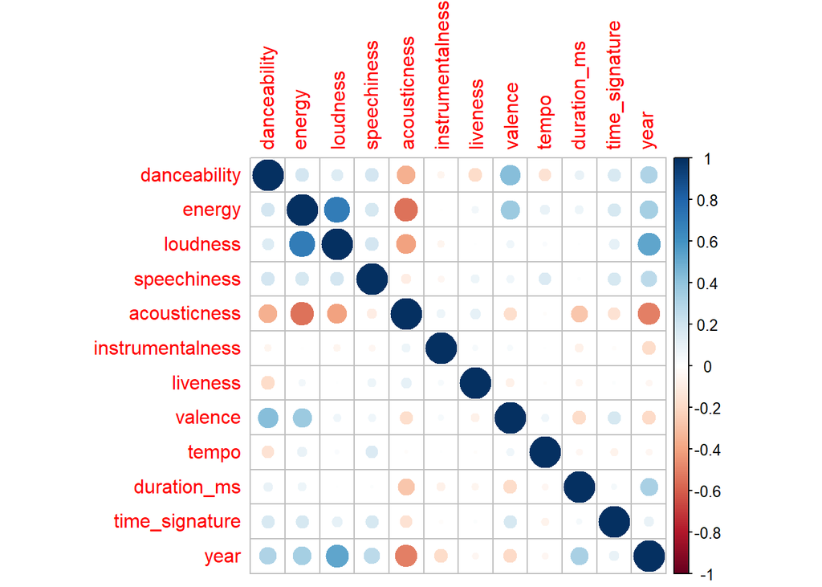

#### Grouping the Data by Decade

| decade | artist_name | n |
| --- | --- | --- |
| 1950 | Bobby Darin | 1 |
| 1950 | Carl Dobkins | 1 |
| 1950 | Domenico Modugno | 1 |
| 1950 | Duane Eddy | 1 |
| 1950 | Elvis Presley | 1 |
| 1950 | Fabian | 1 |
| 1950 | Jack Scott | 1 |
| 1950 | Jimmy Clanton | 1 |
| 1950 | Johnny Horton | 1 |
| 1950 | Lloyd Price | 1 |

[output cut: 499 more lines]

#### Visualization of Grouped Data by Decade

| danceability | energy | key | loudness | mode | speechiness | acousticness | instrumentalness | liveness | valence | tempo | track_uri | duration_ms | time_signature | key_mode | playlist_name | playlist_img | track_name | artist_name | album_name | album_img | decade |
| --- | --- | --- | --- | --- | --- | --- | --- | --- | --- | --- | --- | --- | --- | --- | --- | --- | --- | --- | --- | --- | --- |
| 0.518 | 0.0600 | A# | -14.887 | major | 0.0441 | 9.87e-01 | 7.87e-06 | 0.1610 | 0.3360 | 127.870 | 006Ndmw2hHxvnLbJsBFnPx | 216373 | 4 | A# major | summer_hits_1958 | https://mosaic.scdn.co/640/5e8c49f7a8d161c1d6510999bd867b6a91640dae6488d1b4d3b17500498b1e648e8a15a663ee1cc083350f7f3e709bffbd6bf47bea2d4132c145484af0f2c3321ca683bdc121ba039b98c13bbf37d6b2 | Nel blu dipinto di blu | Domenico Modugno | Tutto Modugno (Mister Volare) | https://i.scdn.co/image/5e8c49f7a8d161c1d6510999bd867b6a91640dae | 1950 |
| 0.543 | 0.3320 | C | -11.573 | major | 0.0317 | 6.69e-01 | 0.00e+00 | 0.1340 | 0.7950 | 154.999 | 5ayybTSXNwcarDtxQKqvWX | 153933 | 4 | C major | summer_hits_1958 | https://mosaic.scdn.co/640/5e8c49f7a8d161c1d6510999bd867b6a91640dae6488d1b4d3b17500498b1e648e8a15a663ee1cc083350f7f3e709bffbd6bf47bea2d4132c145484af0f2c3321ca683bdc121ba039b98c13bbf37d6b2 | Poor Little Fool | Ricky Nelson | Ricky Nelson (Expanded Edition / Remastered) | https://i.scdn.co/image/f0f2c3321ca683bdc121ba039b98c13bbf37d6b2 | 1950 |
| 0.541 | 0.6760 | C | -7.988 | major | 0.1350 | 1.88e-01 | 8.03e-01 | 0.1230 | 0.9110 | 76.231 | 4jmFSkpcqLOUN6scGU6BOO | 128360 | 4 | C major | summer_hits_1958 | https://mosaic.scdn.co/640/5e8c49f7a8d161c1d6510999bd867b6a91640dae6488d1b4d3b17500498b1e648e8a15a663ee1cc083350f7f3e709bffbd6bf47bea2d4132c145484af0f2c3321ca683bdc121ba039b98c13bbf37d6b2 | Patricia | Pérez Prado | El Rey Del Mambo | https://i.scdn.co/image/6488d1b4d3b17500498b1e648e8a15a663ee1cc0 | 1950 |
| 0.408 | 0.3970 | A | -12.536 | major | 0.0300 | 8.73e-01 | 0.00e+00 | 0.2800 | 0.6970 | 72.615 | 3c7KT5CN8uYRaK3xThhdYt | 162773 | 4 | A major | summer_hits_1958 | https://mosaic.scdn.co/640/5e8c49f7a8d161c1d6510999bd867b6a91640dae6488d1b4d3b17500498b1e648e8a15a663ee1cc083350f7f3e709bffbd6bf47bea2d4132c145484af0f2c3321ca683bdc121ba039b98c13bbf37d6b2 | Little Star | The Elegants | Little Star: The Best Of The Elegants | https://i.scdn.co/image/83350f7f3e709bffbd6bf47bea2d4132c145484a | 1950 |
| 0.554 | 0.1890 | E | -14.277 | major | 0.0279 | 9.15e-01 | 1.37e-05 | 0.1320 | 0.2140 | 136.714 | 2urRqmAFhjZKo8Z6sEGzEv | 165293 | 3 | E major | summer_hits_1958 | https://mosaic.scdn.co/640/5e8c49f7a8d161c1d6510999bd867b6a91640dae6488d1b4d3b17500498b1e648e8a15a663ee1cc083350f7f3e709bffbd6bf47bea2d4132c145484af0f2c3321ca683bdc121ba039b98c13bbf37d6b2 | My True Love | Jack Scott | Best Of The Rockabilly Years | https://i.scdn.co/image/9105f52cfba8e58051ecedf325e17ffc6ab3287d | 1950 |
| 0.679 | 0.2790 | G | -10.386 | major | 0.0384 | 6.45e-01 | 0.00e+00 | 0.1180 | 0.8540 | 117.287 | 1tKMOJW1eTIMSNtILF0ce9 | 161253 | 3 | G major | summer_hits_1958 | https://mosaic.scdn.co/640/5e8c49f7a8d161c1d6510999bd867b6a91640dae6488d1b4d3b17500498b1e648e8a15a663ee1cc083350f7f3e709bffbd6bf47bea2d4132c145484af0f2c3321ca683bdc121ba039b98c13bbf37d6b2 | Just A Dream | Jimmy Clanton | R & B Megahits Of The 1950's - Volume 2 | https://i.scdn.co/image/a036b49a7c34b0313af3c6aece152a5fbaa1770c | 1950 |
| 0.663 | 0.6190 | F# | -5.731 | major | 0.0334 | 3.36e-01 | 8.61e-06 | 0.0622 | 0.9790 | 185.165 | 112ZDj3BKudS0w9nKFzJPN | 150600 | 4 | F# major | summer_hits_1958 | https://mosaic.scdn.co/640/5e8c49f7a8d161c1d6510999bd867b6a91640dae6488d1b4d3b17500498b1e648e8a15a663ee1cc083350f7f3e709bffbd6bf47bea2d4132c145484af0f2c3321ca683bdc121ba039b98c13bbf37d6b2 | When (Originally Performed By The Kalin Twins) [Full Vocal Version] | Paris Music | Karaoke Hits 1958, Vol. 2 | https://i.scdn.co/image/d6468bb20e92587d38429ad8a31232d8861fd1c6 | 1950 |
| 0.684 | 0.5560 | B | -10.602 | major | 0.0377 | 4.68e-01 | 0.00e+00 | 0.0664 | 0.8670 | 142.779 | 7mDEao1ygvaaYNIsVDEmg2 | 138733 | 4 | B major | summer_hits_1958 | https://mosaic.scdn.co/640/5e8c49f7a8d161c1d6510999bd867b6a91640dae6488d1b4d3b17500498b1e648e8a15a663ee1cc083350f7f3e709bffbd6bf47bea2d4132c145484af0f2c3321ca683bdc121ba039b98c13bbf37d6b2 | Bird Dog | The Everly Brothers | Rock & Roll | https://i.scdn.co/image/e1ce1316cf44ea0130a0c572b7ab98cb3563b93d | 1950 |
| 0.645 | 0.9430 | C | -1.526 | major | 0.0393 | 3.85e-01 | 0.00e+00 | 0.3700 | 0.9650 | 147.768 | 40fD7ct05FvQHLdQTgJelG | 131720 | 4 | C major | summer_hits_1958 | https://mosaic.scdn.co/640/5e8c49f7a8d161c1d6510999bd867b6a91640dae6488d1b4d3b17500498b1e648e8a15a663ee1cc083350f7f3e709bffbd6bf47bea2d4132c145484af0f2c3321ca683bdc121ba039b98c13bbf37d6b2 | Splish Splash | Bobby Darin | Bobby Darin | https://i.scdn.co/image/975278e9e3a15486bc087f225f252ed0c53ca1c0 | 1950 |
| 0.388 | 0.4340 | G | -11.997 | major | 0.0354 | 7.89e-01 | 9.54e-01 | 0.7280 | 0.8730 | 206.313 | 4nAJtcmiyoL0ARY5WZY9IN | 153533 | 4 | G major | summer_hits_1958 | https://mosaic.scdn.co/640/5e8c49f7a8d161c1d6510999bd867b6a91640dae6488d1b4d3b17500498b1e648e8a15a663ee1cc083350f7f3e709bffbd6bf47bea2d4132c145484af0f2c3321ca683bdc121ba039b98c13bbf37d6b2 | Rebel Rouser | Duane Eddy | The Best Of Duane Eddy | https://i.scdn.co/image/51bf334b15058b39192bda36a4e2b040d933f6b0 | 1950 |

[output cut: 590 more lines]

#### Creating Data Means of Numeric Variables.

#### Creating Summary Statistics

|  | danceability | energy | loudness | speechiness | acousticness | instrumentalness | liveness | valence | tempo | duration_ms | time_signature | decade |
| --- | --- | --- | --- | --- | --- | --- | --- | --- | --- | --- | --- | --- |
| Min. | 0.2170000 | 0.0600000 | -23.57400 | 0.023300 | 0.0000488 | 0.0000000 | 0.0248000 | 0.0695000 | 62.8290 | 103386.0 | 3.000000 | 1950 |
| 1st Qu. | 0.5457500 | 0.4767500 | -10.94725 | 0.032800 | 0.0417250 | 0.0000000 | 0.0859500 | 0.4790000 | 100.2155 | 192886.8 | 4.000000 | 1970 |
| Median | 0.6480000 | 0.6405000 | -8.07150 | 0.041400 | 0.1620000 | 0.0000032 | 0.1240000 | 0.6900000 | 120.0070 | 226926.5 | 4.000000 | 1980 |
| Mean | 0.6407033 | 0.6220855 | -8.58655 | 0.068661 | 0.2665156 | 0.0364316 | 0.1797937 | 0.6488397 | 120.4817 | 229434.0 | 3.971667 | 1983 |
| 3rd Qu. | 0.7402500 | 0.7830000 | -5.86175 | 0.069900 | 0.4472500 | 0.0007132 | 0.2227500 | 0.8482500 | 133.8350 | 257853.5 | 4.000000 | 2000 |
| Max. | 0.9800000 | 0.9890000 | -1.09700 | 0.517000 | 0.9870000 | 0.9540000 | 0.9890000 | 0.9860000 | 210.7500 | 557293.0 | 5.000000 | 2010 |

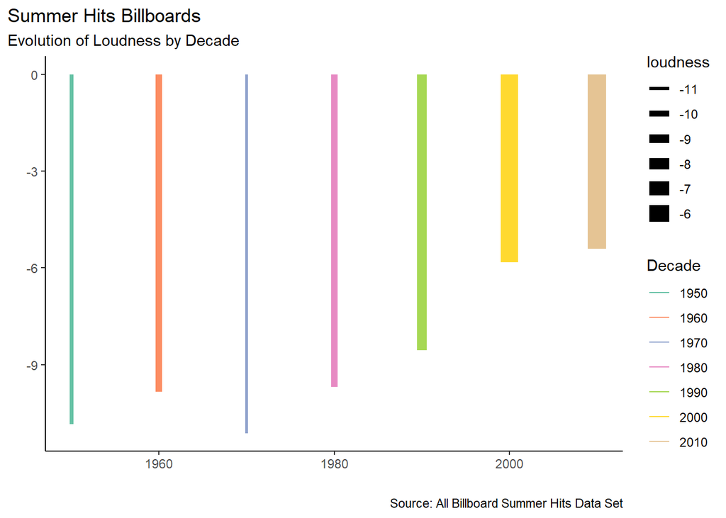

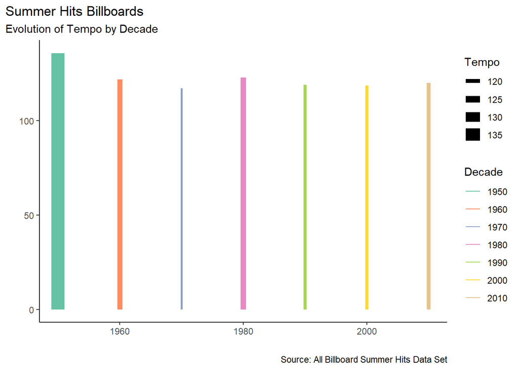

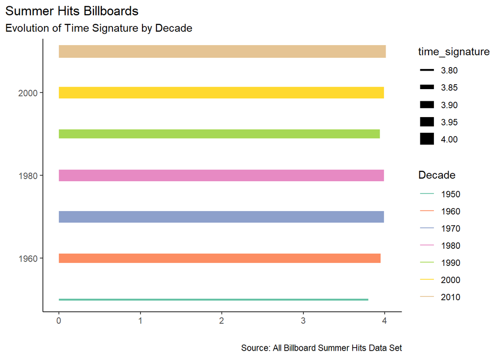

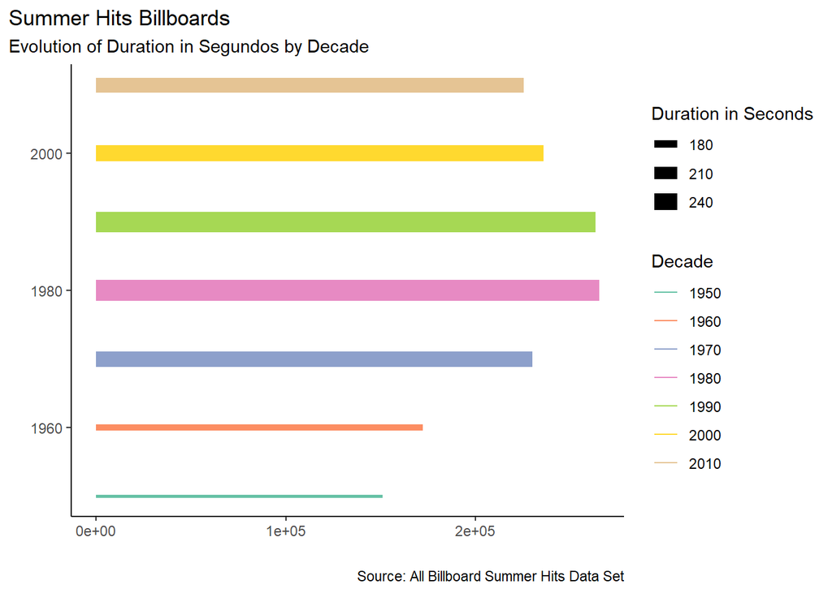

#### Transposing Data Set for Multiple Line Visualization

| decade | variable | value |
| --- | --- | --- |
| 1950 | danceability | 0.57665000 |
| 1950 | energy | 0.48680000 |
| 1950 | speechiness | 0.04868500 |
| 1950 | acousticness | 0.63654500 |
| 1950 | instrumentalness | 0.13467162 |
| 1950 | liveness | 0.21859500 |
| 1950 | valence | 0.76520000 |
| 1960 | danceability | 0.55909000 |
| 1960 | energy | 0.54558700 |
| 1960 | speechiness | 0.05570100 |

[output cut: 39 more lines]

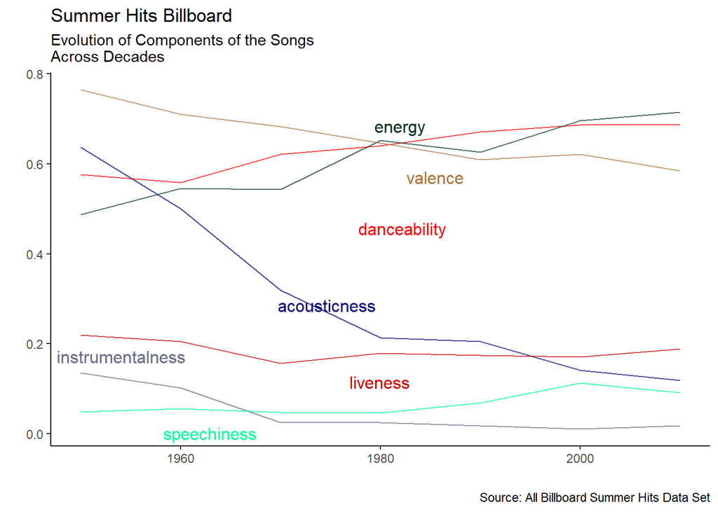

#### Creating Data Frame of Non-numeric Variables.

#### Visualization of Non-numeric Variables.

| decade | key | mode | track_uri | key_mode | playlist_name | playlist_img | track_name | artist_name | album_name | album_img |
| --- | --- | --- | --- | --- | --- | --- | --- | --- | --- | --- |
| 1950 | A# | major | 006Ndmw2hHxvnLbJsBFnPx | A# major | summer_hits_1958 | https://mosaic.scdn.co/640/5e8c49f7a8d161c1d6510999bd867b6a91640dae6488d1b4d3b17500498b1e648e8a15a663ee1cc083350f7f3e709bffbd6bf47bea2d4132c145484af0f2c3321ca683bdc121ba039b98c13bbf37d6b2 | Nel blu dipinto di blu | Domenico Modugno | Tutto Modugno (Mister Volare) | https://i.scdn.co/image/5e8c49f7a8d161c1d6510999bd867b6a91640dae |
| 1950 | C | major | 5ayybTSXNwcarDtxQKqvWX | C major | summer_hits_1958 | https://mosaic.scdn.co/640/5e8c49f7a8d161c1d6510999bd867b6a91640dae6488d1b4d3b17500498b1e648e8a15a663ee1cc083350f7f3e709bffbd6bf47bea2d4132c145484af0f2c3321ca683bdc121ba039b98c13bbf37d6b2 | Poor Little Fool | Ricky Nelson | Ricky Nelson (Expanded Edition / Remastered) | https://i.scdn.co/image/f0f2c3321ca683bdc121ba039b98c13bbf37d6b2 |
| 1950 | C | major | 4jmFSkpcqLOUN6scGU6BOO | C major | summer_hits_1958 | https://mosaic.scdn.co/640/5e8c49f7a8d161c1d6510999bd867b6a91640dae6488d1b4d3b17500498b1e648e8a15a663ee1cc083350f7f3e709bffbd6bf47bea2d4132c145484af0f2c3321ca683bdc121ba039b98c13bbf37d6b2 | Patricia | Pérez Prado | El Rey Del Mambo | https://i.scdn.co/image/6488d1b4d3b17500498b1e648e8a15a663ee1cc0 |
| 1950 | A | major | 3c7KT5CN8uYRaK3xThhdYt | A major | summer_hits_1958 | https://mosaic.scdn.co/640/5e8c49f7a8d161c1d6510999bd867b6a91640dae6488d1b4d3b17500498b1e648e8a15a663ee1cc083350f7f3e709bffbd6bf47bea2d4132c145484af0f2c3321ca683bdc121ba039b98c13bbf37d6b2 | Little Star | The Elegants | Little Star: The Best Of The Elegants | https://i.scdn.co/image/83350f7f3e709bffbd6bf47bea2d4132c145484a |
| 1950 | E | major | 2urRqmAFhjZKo8Z6sEGzEv | E major | summer_hits_1958 | https://mosaic.scdn.co/640/5e8c49f7a8d161c1d6510999bd867b6a91640dae6488d1b4d3b17500498b1e648e8a15a663ee1cc083350f7f3e709bffbd6bf47bea2d4132c145484af0f2c3321ca683bdc121ba039b98c13bbf37d6b2 | My True Love | Jack Scott | Best Of The Rockabilly Years | https://i.scdn.co/image/9105f52cfba8e58051ecedf325e17ffc6ab3287d |
| 1950 | G | major | 1tKMOJW1eTIMSNtILF0ce9 | G major | summer_hits_1958 | https://mosaic.scdn.co/640/5e8c49f7a8d161c1d6510999bd867b6a91640dae6488d1b4d3b17500498b1e648e8a15a663ee1cc083350f7f3e709bffbd6bf47bea2d4132c145484af0f2c3321ca683bdc121ba039b98c13bbf37d6b2 | Just A Dream | Jimmy Clanton | R & B Megahits Of The 1950's - Volume 2 | https://i.scdn.co/image/a036b49a7c34b0313af3c6aece152a5fbaa1770c |
| 1950 | F# | major | 112ZDj3BKudS0w9nKFzJPN | F# major | summer_hits_1958 | https://mosaic.scdn.co/640/5e8c49f7a8d161c1d6510999bd867b6a91640dae6488d1b4d3b17500498b1e648e8a15a663ee1cc083350f7f3e709bffbd6bf47bea2d4132c145484af0f2c3321ca683bdc121ba039b98c13bbf37d6b2 | When (Originally Performed By The Kalin Twins) [Full Vocal Version] | Paris Music | Karaoke Hits 1958, Vol. 2 | https://i.scdn.co/image/d6468bb20e92587d38429ad8a31232d8861fd1c6 |
| 1950 | B | major | 7mDEao1ygvaaYNIsVDEmg2 | B major | summer_hits_1958 | https://mosaic.scdn.co/640/5e8c49f7a8d161c1d6510999bd867b6a91640dae6488d1b4d3b17500498b1e648e8a15a663ee1cc083350f7f3e709bffbd6bf47bea2d4132c145484af0f2c3321ca683bdc121ba039b98c13bbf37d6b2 | Bird Dog | The Everly Brothers | Rock & Roll | https://i.scdn.co/image/e1ce1316cf44ea0130a0c572b7ab98cb3563b93d |
| 1950 | C | major | 40fD7ct05FvQHLdQTgJelG | C major | summer_hits_1958 | https://mosaic.scdn.co/640/5e8c49f7a8d161c1d6510999bd867b6a91640dae6488d1b4d3b17500498b1e648e8a15a663ee1cc083350f7f3e709bffbd6bf47bea2d4132c145484af0f2c3321ca683bdc121ba039b98c13bbf37d6b2 | Splish Splash | Bobby Darin | Bobby Darin | https://i.scdn.co/image/975278e9e3a15486bc087f225f252ed0c53ca1c0 |
| 1950 | G | major | 4nAJtcmiyoL0ARY5WZY9IN | G major | summer_hits_1958 | https://mosaic.scdn.co/640/5e8c49f7a8d161c1d6510999bd867b6a91640dae6488d1b4d3b17500498b1e648e8a15a663ee1cc083350f7f3e709bffbd6bf47bea2d4132c145484af0f2c3321ca683bdc121ba039b98c13bbf37d6b2 | Rebel Rouser | Duane Eddy | The Best Of Duane Eddy | https://i.scdn.co/image/51bf334b15058b39192bda36a4e2b040d933f6b0 |

[output cut: 590 more lines]

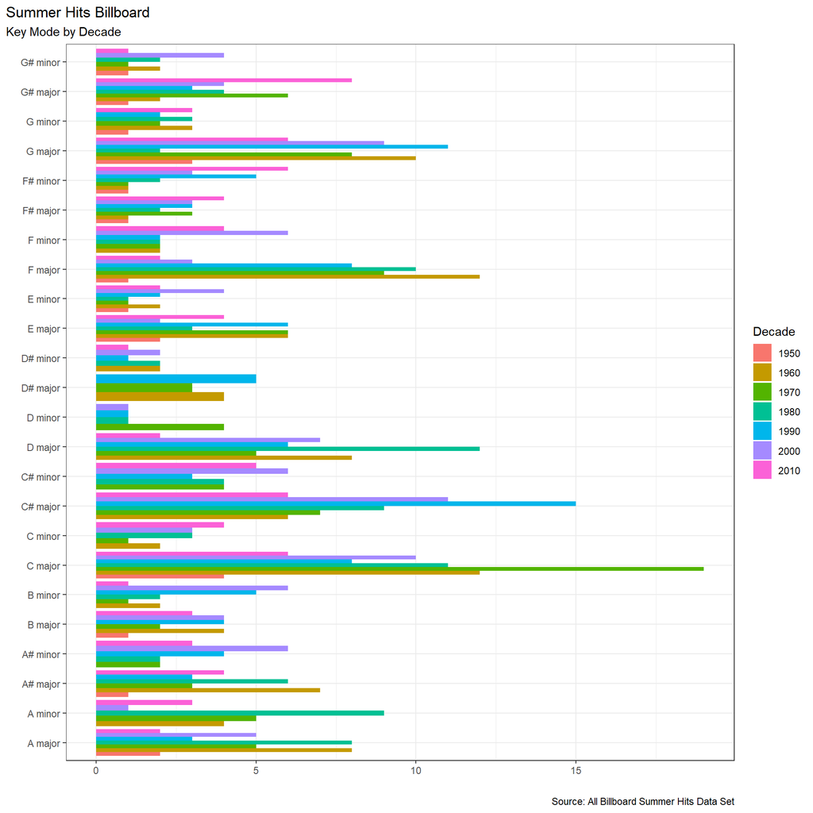

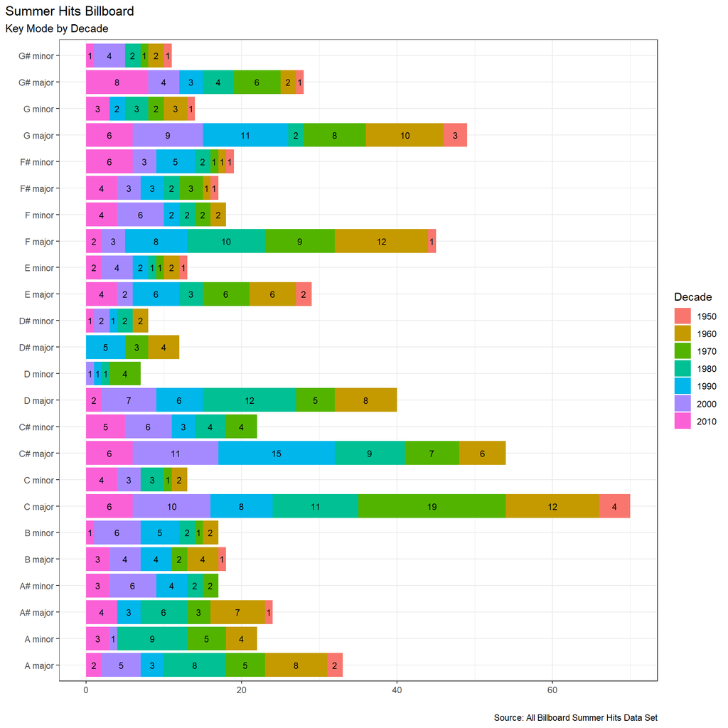

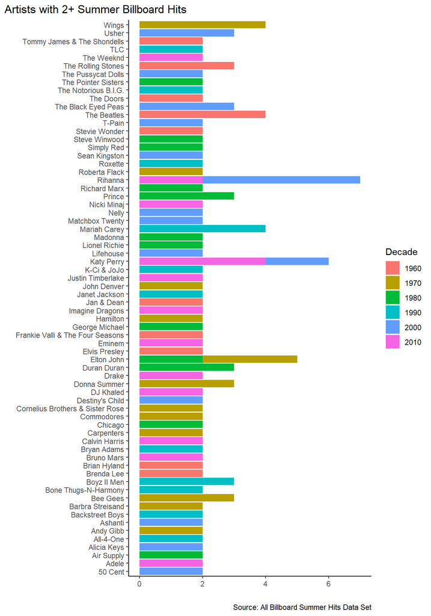

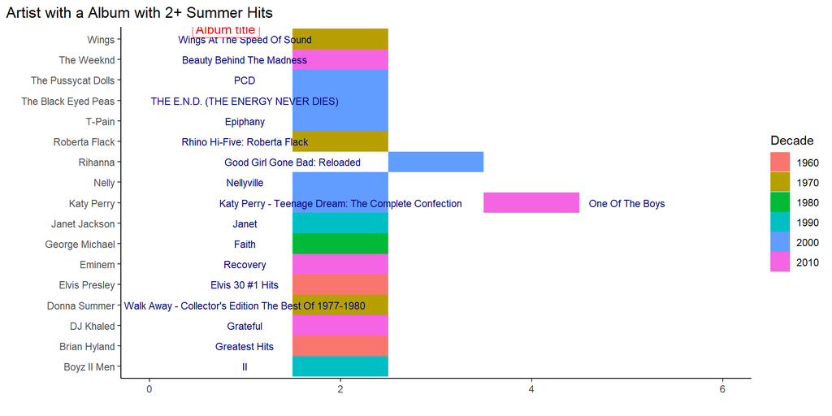

## Student Habits performance

#### Reading Data Set Structure.

```
## 'data.frame':    1000 obs. of  16 variables:
##  $ student_id                   : chr  "S1000" "S1001" "S1002" "S1003" ...
##  $ age                          : int  23 20 21 23 19 24 21 21 23 18 ...
##  $ gender                       : chr  "Female" "Female" "Male" "Female" ...
##  $ study_hours_per_day          : num  0 6.9 1.4 1 5 7.2 5.6 4.3 4.4 4.8 ...
##  $ social_media_hours           : num  1.2 2.8 3.1 3.9 4.4 1.3 1.5 1 2.2 3.1 ...
##  $ netflix_hours                : num  1.1 2.3 1.3 1 0.5 0 1.4 2 1.7 1.3 ...
##  $ part_time_job                : chr  "No" "No" "No" "No" ...
##  $ attendance_percentage        : num  85 97.3 94.8 71 90.9 82.9 85.8 77.7 100 95.4 ...
##  $ sleep_hours                  : num  8 4.6 8 9.2 4.9 7.4 6.5 4.6 7.1 7.5 ...
##  $ diet_quality                 : chr  "Fair" "Good" "Poor" "Poor" ...
##  $ exercise_frequency           : int  6 6 1 4 3 1 2 0 3 5 ...
##  $ parental_education_level     : chr  "Master" "High School" "High School" "Master" ...
##  $ internet_quality             : chr  "Average" "Average" "Poor" "Good" ...
##  $ mental_health_rating         : int  8 8 1 1 1 4 4 8 1 10 ...
##  $ extracurricular_participation: chr  "Yes" "No" "No" "Yes" ...
##  $ exam_score                   : num  56.2 100 34.3 26.8 66.4 100 89.8 72.6 78.9 100 ...
```

#### Creating data set Histogram

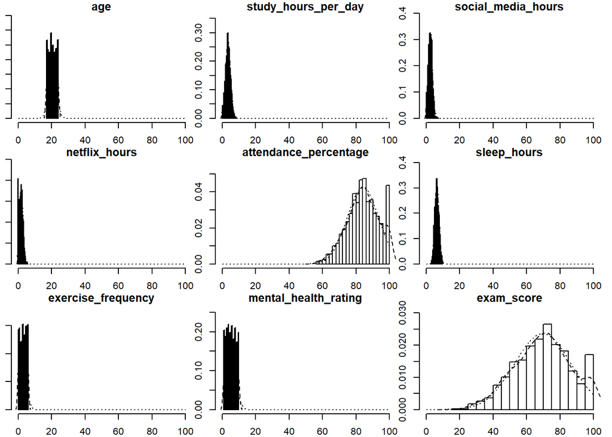

#### Summary Statistics

|  | age | study_hours_per_day | social_media_hours | netflix_hours | attendance_percentage | sleep_hours | exercise_frequency | mental_health_rating | exam_score |
| --- | --- | --- | --- | --- | --- | --- | --- | --- | --- |
|  | Min. :17.00 | Min. :0.00 | Min. :0.000 | Min. :0.000 | Min. : 56.00 | Min. : 3.20 | Min. :0.000 | Min. : 1.000 | Min. : 18.40 |
|  | 1st Qu.:18.75 | 1st Qu.:2.60 | 1st Qu.:1.700 | 1st Qu.:1.000 | 1st Qu.: 78.00 | 1st Qu.: 5.60 | 1st Qu.:1.000 | 1st Qu.: 3.000 | 1st Qu.: 58.48 |
|  | Median :20.00 | Median :3.50 | Median :2.500 | Median :1.800 | Median : 84.40 | Median : 6.50 | Median :3.000 | Median : 5.000 | Median : 70.50 |
|  | Mean :20.50 | Mean :3.55 | Mean :2.506 | Mean :1.820 | Mean : 84.13 | Mean : 6.47 | Mean :3.042 | Mean : 5.438 | Mean : 69.60 |
|  | 3rd Qu.:23.00 | 3rd Qu.:4.50 | 3rd Qu.:3.300 | 3rd Qu.:2.525 | 3rd Qu.: 91.03 | 3rd Qu.: 7.30 | 3rd Qu.:5.000 | 3rd Qu.: 8.000 | 3rd Qu.: 81.33 |
|  | Max. :24.00 | Max. :8.30 | Max. :7.200 | Max. :5.400 | Max. :100.00 | Max. :10.00 | Max. :6.000 | Max. :10.000 | Max. :100.00 |

#### Correlation Analysis.

|  | age | study_hours_per_day | social_media_hours | netflix_hours | attendance_percentage | sleep_hours | exercise_frequency | mental_health_rating | exam_score |
| --- | --- | --- | --- | --- | --- | --- | --- | --- | --- |
| age | 1.0000000 | 0.0039712 | -0.0091512 | -0.0011741 | -0.0260552 | 0.0374819 | -0.0038362 | -0.0451014 | -0.0089069 |
| study_hours_per_day | 0.0039712 | 1.0000000 | 0.0202823 | -0.0311583 | 0.0262641 | -0.0277571 | -0.0287012 | -0.0037678 | 0.8254185 |
| social_media_hours | -0.0091512 | 0.0202823 | 1.0000000 | 0.0114766 | 0.0404788 | 0.0182363 | -0.0373190 | 0.0014965 | -0.1667329 |
| netflix_hours | -0.0011741 | -0.0311583 | 0.0114766 | 1.0000000 | -0.0020915 | -0.0009345 | -0.0064482 | 0.0080342 | -0.1717792 |
| attendance_percentage | -0.0260552 | 0.0262641 | 0.0404788 | -0.0020915 | 1.0000000 | 0.0137561 | -0.0078572 | -0.0187446 | 0.0898356 |
| sleep_hours | 0.0374819 | -0.0277571 | 0.0182363 | -0.0009345 | 0.0137561 | 1.0000000 | 0.0197690 | -0.0065080 | 0.1216829 |
| exercise_frequency | -0.0038362 | -0.0287012 | -0.0373190 | -0.0064482 | -0.0078572 | 0.0197690 | 1.0000000 | -0.0002423 | 0.1601075 |
| mental_health_rating | -0.0451014 | -0.0037678 | 0.0014965 | 0.0080342 | -0.0187446 | -0.0065080 | -0.0002423 | 1.0000000 | 0.3215229 |
| exam_score | -0.0089069 | 0.8254185 | -0.1667329 | -0.1717792 | 0.0898356 | 0.1216829 | 0.1601075 | 0.3215229 | 1.0000000 |

#### Heat Map Visualization

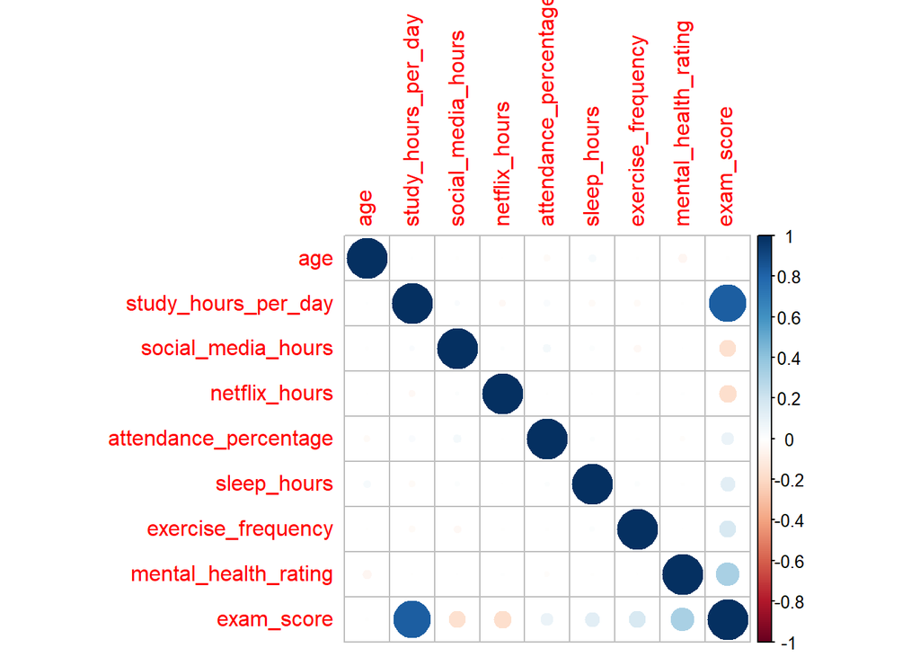

#### Visualization of Data Structure

|  | x |
| --- | --- |
| student_id | character |
| age | integer |
| gender | character |
| study_hours_per_day | double |
| social_media_hours | double |
| netflix_hours | double |
| part_time_job | character |
| attendance_percentage | double |
| sleep_hours | double |
| diet_quality | character |
| exercise_frequency | integer |
| parental_education_level | character |
| internet_quality | character |
| mental_health_rating | integer |
| extracurricular_participation | character |
| exam_score | double |

#### Linear Regression Analysis.

#### Linear Regression Results.

```
##
## Call:
## lm(formula = exam_score ~ ., data = select(students, -c(student_id)))
##
## Residuals:
##      Min       1Q   Median       3Q      Max
## -22.2097  -3.4768   0.0789   3.4456  15.5955
##
## Coefficients:
##                                     Estimate Std. Error t value Pr(>|t|)
## (Intercept)                          7.17718    2.50263   2.868  0.00422 **
## age                                 -0.01209    0.07365  -0.164  0.86959
## genderMale                           0.14621    0.34805   0.420  0.67452
## genderOther                          0.79264    0.86559   0.916  0.36003
## study_hours_per_day                  9.57454    0.11577  82.700  < 2e-16 ***
## social_media_hours                  -2.60220    0.14489 -17.960  < 2e-16 ***
## netflix_hours                       -2.28156    0.15777 -14.462  < 2e-16 ***
## part_time_jobYes                     0.21121    0.41410   0.510  0.61013
## attendance_percentage                0.14339    0.01821   7.876 8.94e-15 ***
## sleep_hours                          1.99234    0.13849  14.386  < 2e-16 ***
## diet_qualityGood                    -0.68310    0.37777  -1.808  0.07088 .
## diet_qualityPoor                    -0.27224    0.47306  -0.575  0.56510
## exercise_frequency                   1.45004    0.08397  17.268  < 2e-16 ***
## parental_education_levelHigh School -0.15995    0.39605  -0.404  0.68639
## parental_education_levelMaster      -0.41093    0.50782  -0.809  0.41860
## parental_education_levelNone        -0.70202    0.63313  -1.109  0.26778
## internet_qualityGood                -0.47289    0.37292  -1.268  0.20507
## internet_qualityPoor                -0.08167    0.50324  -0.162  0.87111
## mental_health_rating                 1.94417    0.06003  32.386  < 2e-16 ***
## extracurricular_participationYes    -0.01412    0.36426  -0.039  0.96909
## ---
## Signif. codes:  0 '***' 0.001 '**' 0.01 '*' 0.05 '.' 0.1 ' ' 1
##
## Residual standard error: 5.342 on 980 degrees of freedom
## Multiple R-squared:  0.9018, Adjusted R-squared:  0.8999
## F-statistic: 473.9 on 19 and 980 DF,  p-value: < 2.2e-16
```

#### Plotting Linear Regression

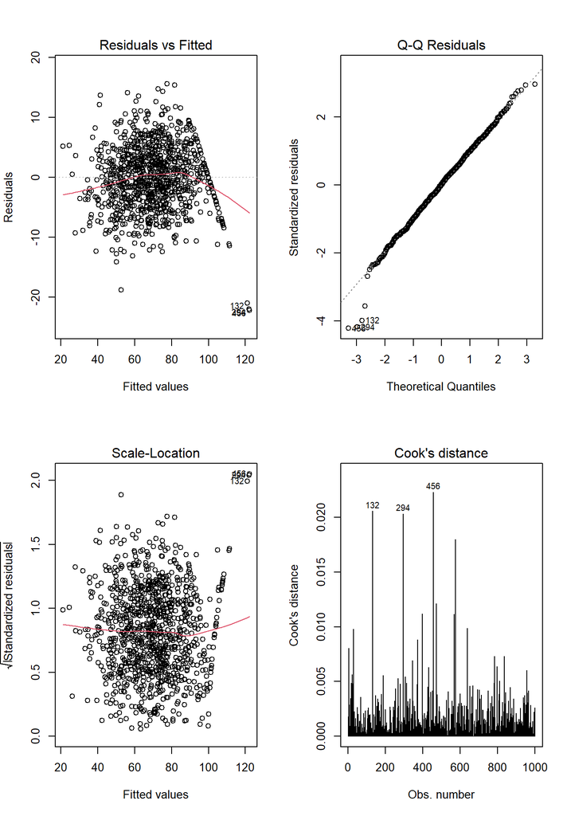

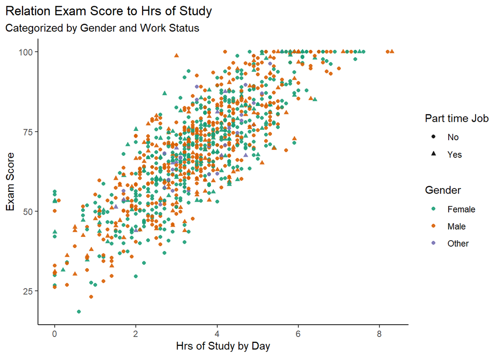

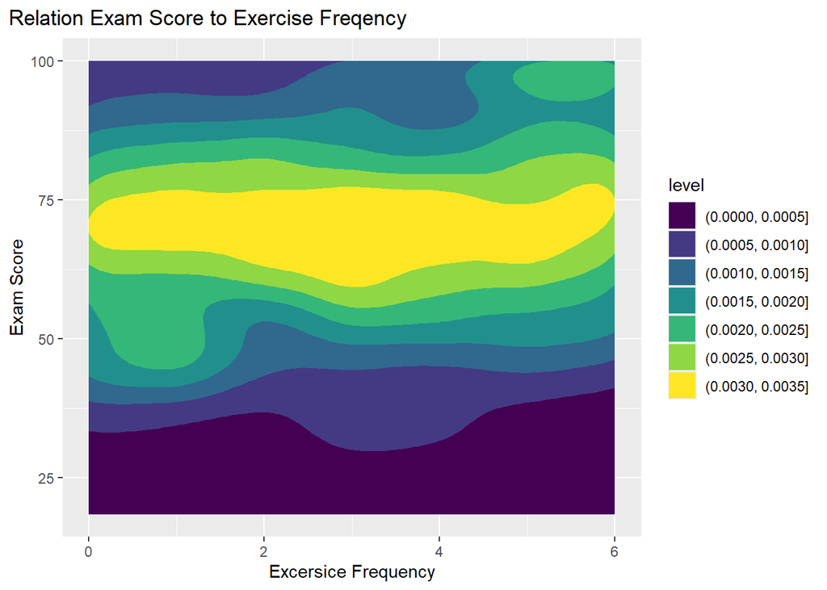

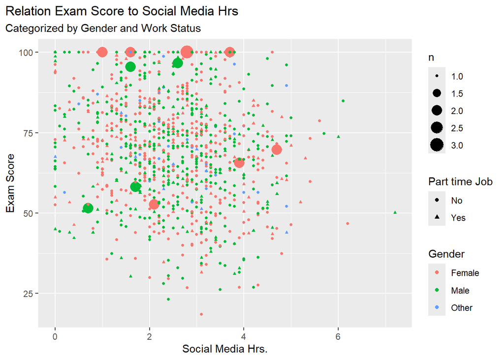

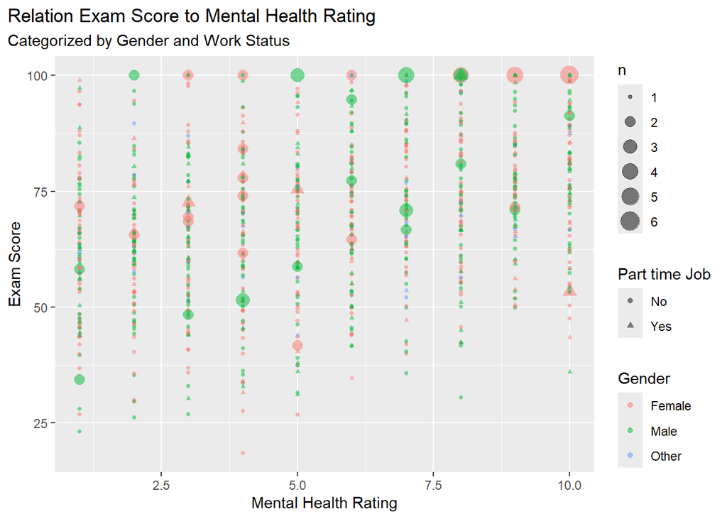

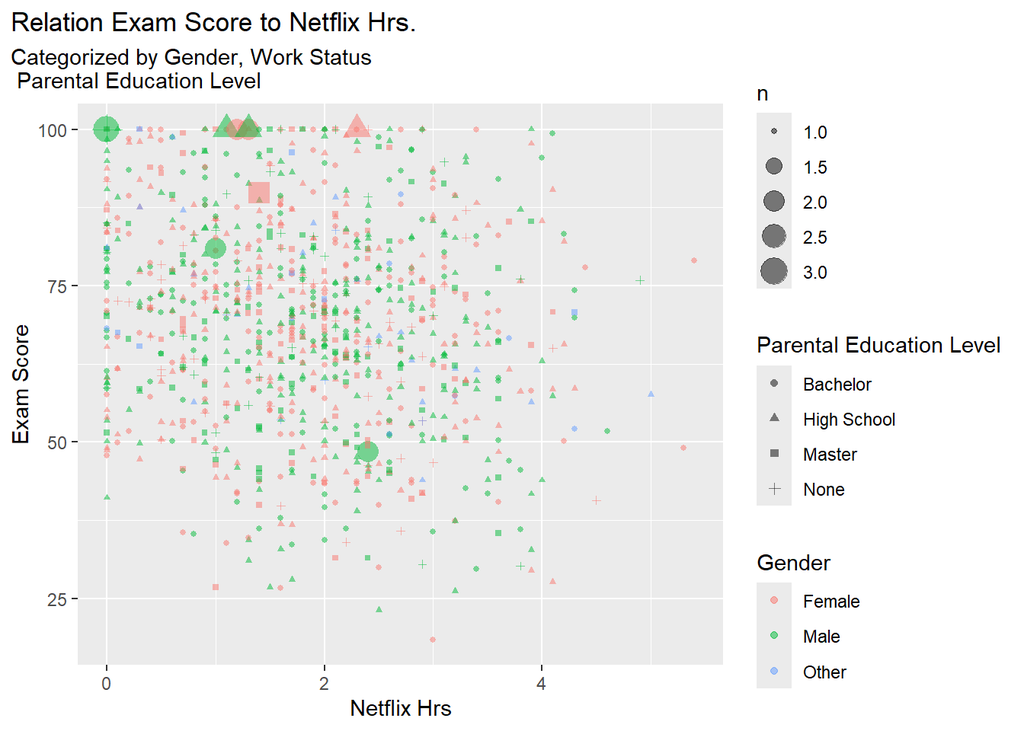

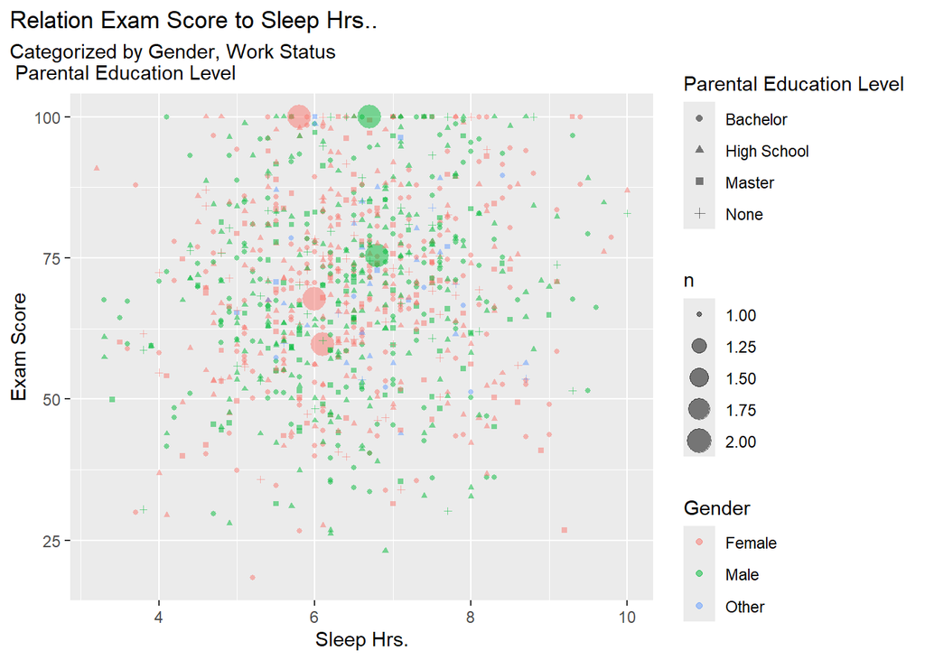

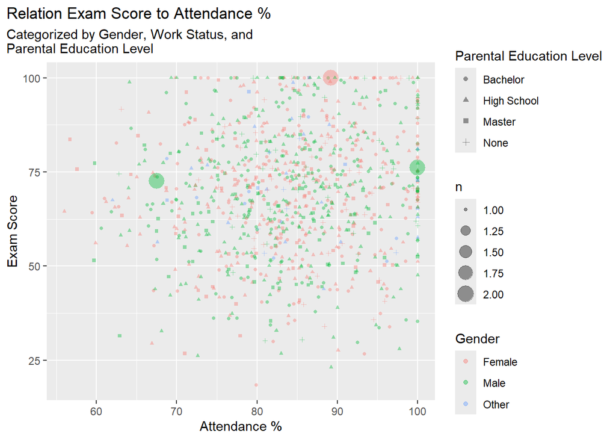